← **Tamu di Bulan**

Edisi contoh: bagian depan buku dan Bab 1–3. Dapatkan buku lengkap

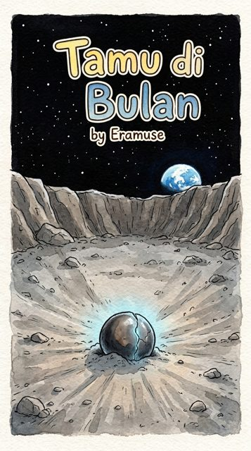

# TAMU DI BULAN

**Buku Kedua dari Tiga**

**Eramuse**

**Untuk segala umur — dibacakan untuk anak 8 tahun ke atas, dan bisa dibaca sendiri oleh anak 10 tahun ke atas**

• • •

### Hak Cipta

**Tamu di Bulan**

Buku Kedua dari Tiga

Penulis: Eramuse

Penerbit: Eramuse House

Cetakan pertama, 2026

Hak cipta © 2026 Eramuse

Hak cipta dilindungi undang-undang. Dilarang memperbanyak, menyalin, atau menyebarluaskan sebagian atau seluruh isi buku ini dalam bentuk apa pun tanpa izin tertulis dari pemegang hak cipta, kecuali untuk kutipan singkat dalam ulasan atau keperluan pendidikan dengan menyebutkan sumbernya.

Guru dan sekolah boleh memperbanyak halaman **Yang Nyata di Bab Ini** dan **Untuk dipikirkan** untuk keperluan mengajar di kelas, tanpa perlu meminta izin.

**Pernyataan fiksi.** Buku ini karya fiksi. Desa Aikbatu dan seluruh tokoh di dalamnya adalah rekaan. Tidak ada tokoh dalam buku ini yang dimaksudkan menggambarkan orang sungguhan, baik yang masih hidup maupun yang sudah meninggal; kemiripan semacam itu, kalau ada, adalah kebetulan semata. Sebagian tempat, lembaga, wahana antariksa, dan peristiwa yang disebut di sini memang nyata, dan dijelaskan satu per satu di bagian belakang buku.

**Keaslian dan koreksi.** Cerita, tokoh, dan seluruh gagasan dalam buku ini disusun sendiri oleh penulis, dengan bantuan kecerdasan buatan sebagaimana dijelaskan di halaman berikutnya. Kalau ada keterangan yang keliru, atau ada sumber yang seharusnya kami sebut tetapi terlewat, tolong beri tahu kami. Akan kami perbaiki pada cetakan berikutnya.

ayomath.com · eramusehouse@gmail.com

• • •

### Beberapa Kata dari Lombok

Cerita ini berlatar di sebuah desa Sasak di Pulau Lombok, dan sebagian di Serpong, dekat Jakarta.

Beberapa kata Sasak dipakai di sepanjang buku. Kata-kata itu dipakai karena tidak ada padanan yang pas dalam bahasa Indonesia, dan karena orang-orang di buku ini memang tidak akan memakai kata lain.

| Kata | Artinya |
| --- | --- |
| **Inaq** | ibu |
| **Amaq** | ayah |
| **Papuq** | kakek atau nenek |
| **Aik** | air |
| **Rowot** | gugusan bintang Pleiades |

**Amaq** juga dipakai untuk laki-laki dewasa yang sudah punya anak. Jadi *Amaq Ripin* kira-kira berarti *bapaknya Ripin*.

**Aikbatu** tidak ada di peta. Namanya disusun dari dua kata Sasak, *aik* dan *batu*. **Sembalun** dan **Rinjani** nyata. **Serpong** juga nyata.

• • •

• • •

### Catatan Kecil

Buku ini ditulis dengan bantuan kecerdasan buatan.

Idenya bukan dari mesin. Tokoh-tokohnya, jalan ceritanya, dan keputusan tentang apa yang masuk dan apa yang dibuang dipilih oleh manusia.

Yang dibantu mesin adalah menyusun kalimat, memeriksa angka, dan menemukan bagian yang keliru.

• • •

• • •

## BAGIAN SATU — SUARA DARI BULAN

### Bab 1 — Sembilan

**Mataram, Lombok. Maret 2028.**

*Dua tahun kemudian, di kota, ada anak dua belas tahun yang menghitung salah.*

Dari jendela kamar kontrakan di Mataram, Jabrik bisa menghitung sembilan bintang.

Ia sudah menghitungnya berkali-kali untuk memastikan. Sembilan. Kadang delapan, kalau langitnya berkabut. Sekali pernah sebelas, waktu listrik satu blok mati semalaman dan ia tidak tidur sampai pagi.

Di Aikbatu ia berhenti menghitung di empat ratus.

• • •

Mereka pindah karena sekolah. Jabrik, Lela, dan Inaq.

Ada yang mengurus, ada yang membayar, ada surat yang ditandatangani Inaq dengan tulisan hati-hati sekali. Jabrik ke SMP yang laboratoriumnya punya mikroskop yang menyala. Lela ke SD yang katanya bagus.

Papuq tidak ikut. Papuq bilang ia sudah tua untuk pindah, dan Rowot tidak kelihatan dari kota.

Dua-duanya benar.

• • •

Di sekolah namanya Ilham.

Tidak ada yang memanggilnya Jabrik. Rambutnya masih berdiri ke segala arah, tapi di Mataram itu tidak cukup menarik untuk dijadikan nama.

Dua tahun lalu ada orang memotretnya setiap hari.

Sekarang tidak ada.

Ia tidak akan mengakuinya kepada siapa pun, tapi kadang ia merindukannya. Dan setiap kali merindukannya, ia merasa malu.

• • •

Hari Kamis itu ia sedang di atap.

Atap kontrakan itu datar, dari beton, dan tangganya di belakang. Inaq melarangnya naik. Ia naik hampir setiap malam.

Di atap ada yang ia kerjakan.

• • •

Ia sedang membuat kotak dari triplek.

Kotak itu untuk menutupi lampu jalan di depan gang. Bukan mematikannya — cuma menutup bagian atasnya, supaya cahayanya turun ke jalan dan tidak naik ke langit.

Ia sudah membaca caranya. Lampu yang bagus mengarahkan cahayanya ke bawah saja. Yang naik ke atas itulah yang menghapus bintang.

Ia belum minta izin siapa-siapa. Ia belum yakin izinnya ke siapa.

• • •

Lela naik ke atap sambil membawa bantal, karena Lela membawa bantal ke mana-mana.

"Buat apa?"

"Biar bintangnya kelihatan."

Lela memandangi kotak triplek itu, lalu memandangi langit, lalu memandangi kakaknya.

"Satu lampu doang?"

"Iya."

"Lampunya banyak, Kak."

"Tahu."

Lela duduk di sebelahnya dan tidak bertanya lagi. Itu salah satu hal yang paling Jabrik sukai dari adiknya.

• • •

Ponsel Inaq berdering jam tiga sore.

"Ilham!" Inaq memanggil dari bawah. "Bu Ratna!"

• • •

Jabrik tidak langsung turun.

Ia membiarkannya berdering, dan menghitungnya sampai enam, sambil masih memegang obengnya.

• • •

Bukan karena ia tidak mau bicara dengan Bu Ratna.

Karena Bu Ratna tidak pernah menelepon untuk menanyakan kabar.

Dua tahun ini Bu Ratna mengiriminya pesan tiga kali. Ulang tahun. Hari raya. Dan sekali waktu ada foto Kira di koran yang salah.

Bu Ratna menelepon kalau ada sesuatu.

• • •

Ia turun pada dering ketujuh, dan Inaq menyerahkan ponselnya tanpa berkata apa-apa.

"Halo, Bu."

"Ilham." Suara Bu Ratna terdengar seperti orang yang sudah menyiapkan kalimatnya dan sekarang lupa. "Tadi di mana?"

"Di atap, Bu."

"Ngapain di atap?"

"Nggak apa-apa."

• • •

"Adikmu ada?"

Jabrik berhenti memegang obengnya.

Dalam dua tahun, Bu Ratna tidak pernah sekali pun menanyakan Lela.

"Ada, Bu. Kenapa?"

• • •

Hening di ujung sana. Bukan hening sambungan. Hening orang berpikir.

"Ilham. Ibu mau tanya sesuatu yang aneh."

"Iya, Bu."

"Waktu kamu ngobrol sama Kira dulu. Kamu pernah bilang 'halo'?"

Jabrik mengerutkan kening. "Ya pernah, Bu. Tiap hari."

"Berapa kali?"

"Mana saya ingat. Ratusan kali."

• • •

Hening lagi, lebih lama.

"Bu Ratna?"

"Besok Ibu ke Mataram," kata Bu Ratna. "Ibu bawa rekaman. Ibu mau kamu dan adikmu dengar."

"Rekaman apa?"

Di ujung sana, Bu Ratna menarik napas.

"Ada yang memanggil dari Bulan," katanya. "Pakai suara kamu."

• • •

Jabrik berdiri di dapur dengan obeng di satu tangan dan ponsel Inaq di tangan yang lain.

Inaq memandanginya dari ambang pintu dan tidak bertanya apa-apa.

Di bawahnya lampu jalan menyala terang ke segala arah, termasuk ke atas, seperti biasa.

Di atasnya ada sembilan bintang.

• • •

#### Yang Nyata di Bab Ini

- **Lampu jalan yang buruk menyorot ke segala arah**, termasuk ke atas. Cahaya yang naik itulah yang menghapus bintang. Lampu yang dirancang baik menutup bagian atasnya, sehingga cahayanya turun ke jalan saja — lebih terang di bawah, dan langitnya tetap gelap.
- **Mata manusia perlu waktu untuk terbiasa gelap.** Sekitar dua puluh menit untuk sebagian besar orang, dan lebih dari setengah jam untuk penuh. Satu kali melihat layar ponsel mengulang prosesnya dari awal.

**Untuk dipikirkan:** Jabrik membuat penutup untuk satu lampu, padahal lampunya ratusan. Menurutmu, apa gunanya?

• • •

• • •

### Bab 2 — Dua Puluh Empat Kali

**Sisi jauh Bulan. Dua tahun terakhir.**

*Di sisi Bulan yang tidak pernah menghadap Bumi, ada yang sudah memanggil selama dua tahun.*

Ada kawah kecil di sisi Bulan yang tidak pernah kita lihat.

Lebarnya tidak sampai dua puluh meter. Tidak ada namanya. Debu yang terlempar waktu kawah itu terbentuk masih berbentuk kipas, persis seperti hari pertama.

Di Bulan tidak ada angin. Tidak ada hujan. Tidak ada apa pun yang bisa menghapus.

Di dasar kawah itu ada bola logam kelabu, setengah terbenam, dengan retakan di satu sisi.

• • •

Dua tahun lalu, bola itu mendengar sesuatu.

Bukan dari Bulan. Dari arah Bumi, waktu Bumi kebetulan terlihat di ufuk.

Isinya banyak sekali. Hampir semuanya tidak ia mengerti.

Tapi ada bagian yang ia mengerti.

• • •

Ada anak laki-laki yang mengajari sesuatu berbicara.

Kata demi kata. Sambil menunjuk. *Ini gayung. Ini batu. Ini air.*

Dan ada anak perempuan yang mengoceh tanpa berhenti tentang ayam dan mimpi, dan tertawa pada hal-hal yang tidak lucu.

Bola itu menyimpan keduanya.

• • •

Sejak itu ia memanggil.

Ia memanggil dengan kata-kata anak laki-laki itu, karena ia tidak punya kata lain.

*Halo.*

• • •

Masalahnya, dari kawah itu, Bumi tidak selalu kelihatan.

Bumi naik pelan sekali di ufuk. Tinggal beberapa hari. Lalu turun lagi, sama pelannya, dan hilang berminggu-minggu.

Setiap kali Bumi naik, bola itu memanggil.

Setiap kali Bumi turun, ia berhenti dan menunggu.

• • •

Dua puluh empat kali, selama dua tahun.

Dua belas atau tiga belas kali setahun. Tidak lebih.

• • •

Tenaganya berkurang sedikit setiap kali.

Ia tahu itu. Ia tidak tahu tinggal berapa banyak.

• • •

Ia tidak tahu apakah kata itu benar.

Tidak ada yang pernah membetulkannya. Di rekaman itu, anak laki-laki itu membetulkan sesuatu yang lain — berkali-kali, sabar, selama berbulan-bulan. *Bukan. Yang ini batu. Yang ini gayung.*

Tapi tidak ada yang membetulkan bola itu.

Jadi setiap kali ia memanggil, ia memanggil dengan nada orang bertanya.

*Halo?*

*Halo? Halo?*

• • •

Bumi bergerak turun, pelan sekali, selama beberapa hari.

Lalu hilang lagi.

• • •

#### Yang Nyata di Bab Ini

- **Bulan selalu menghadapkan sisi yang sama ke Bumi.** Karena itu ada sisi yang tidak pernah kita lihat dari sini. Namanya sisi jauh, bukan sisi gelap — sisi itu kena matahari sama banyaknya.
- **Di Bulan tidak ada udara, angin, atau hujan.** Jejak kaki dan bekas benturan bisa bertahan jutaan tahun tanpa berubah.

**Untuk dipikirkan:** Bola itu memanggil dua puluh empat kali tanpa pernah tahu apakah kata yang ia pakai benar. Pernahkah kamu memakai kata yang ternyata artinya lain?

• • •

• • •

### Bab 3 — Rekaman

**Mataram. Hari ke-19 sebelum kontak pertama.**

*Dua puluh empat kali, selama dua tahun, dan tidak ada yang mendengarkan.*

Bu Ratna datang dengan laptop dan wajah orang yang tidak tidur di pesawat.

Ia lebih tua dari dua tahun lalu. Rambutnya lebih banyak yang putih. Sepatu lapangannya masih yang itu juga, masih rusak di ujung yang sama.

"Papuq apa kabar?"

"Baik, Bu. Masih di Aikbatu."

"Bagus." Ia meletakkan laptopnya di meja plastik.

"Ibu masih di BRIN," katanya, tanpa ditanya. "Badan Riset dan Inovasi Nasional. Kantor penelitian pemerintah."

"Saya tahu, Bu."

"Ibu tahu kamu tahu. Ibu cuma belum pernah bilang."

Ia menarik kursi.

"Duduk. Kalian berdua."

• • •

Inaq membawakan teh dan tidak keluar dari ruangan.

Itu tidak biasa. Dua tahun lalu Inaq selalu keluar kalau ada orang penting datang.

Bu Ratna memperhatikannya, dan tidak berkata apa-apa, dan Jabrik tahu bahwa Bu Ratna sudah memutuskan Inaq boleh ikut mendengar.

• • •

"Ini panjangnya empat detik," kata Bu Ratna. "Ibu putar tiga kali. Jangan bilang apa-apa dulu."

Lela duduk di lantai, karena Lela selalu duduk di lantai.

Bu Ratna menekan tombolnya.

• • •

Mula-mula desis. Seperti hujan jauh.

Lalu ada suara.

*"Halo."*

Pelan. Agak pecah. Seperti orang bicara dari balik dinding.

*"Halo. Halo."*

• • •

Jabrik merasa lehernya dingin.

Bukan karena suara itu asing.

Karena suara itu suaranya. Umur sepuluh tahun. Sebelum suaranya berubah.

Ia belum pernah mendengar suaranya sendiri yang dulu. Tidak ada yang pernah merekamnya. Keluarganya tidak punya kebiasaan merekam apa-apa.

Ternyata beginilah bunyinya.

• • •

Di sebelahnya, Inaq meletakkan gelasnya dengan sangat pelan, seperti orang yang tidak mau membuat suara.

• • •

Bu Ratna memutarnya kedua kali.

Kali ini Jabrik mendengar sesuatu yang lebih buruk.

Ada jeda di antara halo yang pertama dan kedua. Jeda yang agak panjang.

Itu jeda menunggu jawaban.

Benda itu bukan sedang bicara. Benda itu memanggil, berhenti, lalu memanggil lagi.

Seperti orang mengetuk pintu rumah yang sudah lama kosong.

• • •

"Bu." Suaranya tidak keluar dengan benar. Ia mencoba lagi. "Bu, itu Kira?"

"Bukan."

"Kok bisa bukan. Itu suara saya."

"Kira di Serpong. Dikunci. Pemancarnya habis waktu mengirim pesanmu dulu." Bu Ratna menutup laptopnya sedikit. "Ibu cek sendiri kemarin."

Ia mengangkat wajahnya.

"Yang ini dari Bulan, Ilham. Dari sisi yang tidak menghadap kita."

• • •

"Berarti ada dua."

"Berarti ada dua."

• • •

Jabrik memandangi meja plastik itu.

Dua tahun lalu ia mengira ia sudah tahu bentuk dunia. Ada satu benda yang jatuh, ia menemukannya, ia mengajarinya bicara, dan selesai.

"Ada berapa, Bu?"

"Ibu tidak tahu."

"Tapi Kira bilang—"

Ia berhenti. Ia ingat persis apa yang Kira bilang. *Bukan ratusan. Bukan ribuan. Lebih dari itu.*

Ia tidak menyelesaikan kalimatnya. Bu Ratna tidak memintanya.

• • •

Lalu Lela bicara dari lantai.

"Dia salah."

Semua orang menoleh.

"Apanya yang salah?"

"Cara bilangnya." Lela mengangkat bahu, seperti orang menjelaskan bahwa air itu basah. "Kakak nggak bilang gitu."

• • •

"Maksudnya gimana, Lela?"

"Kakak bilang *halo*." Ia mengucapkannya turun di akhir. Datar. Seperti menyapa. "Yang di rekaman *halo*." Naik sedikit di akhir.

Ia memutar tangannya.

"Kayak nanya. Kakak nggak nanya."

• • •

Bu Ratna tidak bergerak selama beberapa detik.

Lalu ia membuka laptopnya lagi, memutar rekaman itu untuk keempat kalinya, dan mendengarkan dengan cara yang berbeda.

"Putar yang pelan, Bu," kata Lela.

Bu Ratna memutarnya pelan.

Lela memiringkan kepala.

"Iya. Nanya."

• • •

"Lela. Kamu yakin?"

Lela memandanginya seperti pertanyaan itu aneh.

"Ya yakin. Aku kan dengar tiap hari."

Ia sudah bosan. Ia berdiri dan pergi mencari kue.

• • •

Yang tinggal di ruangan itu tiga orang.

"Bu," kata Jabrik pelan. "Kalau dia nanya, berarti dia nunggu dijawab."

"Iya."

"Sudah dua tahun."

"Iya."

• • •

Bu Ratna menutup laptopnya sampai bunyi klik.

"Dua puluh empat kali, Ilham. Dan tidak ada satu pun yang menjawab."

• • •

"Bu. Kapan dia manggil lagi?"

Bu Ratna sudah menunggu pertanyaan itu.

"Benda itu tidak bisa mendengar kita setiap hari. Dari tempat dia tergeletak, Bumi cuma kelihatan beberapa hari, sekali sebulan."

"Kenapa?"

"Nanti ada yang jelaskan. Yang jelas, kalau Buminya tidak kelihatan, dia tidak bisa dengar apa-apa."

• • •

"Sembilan belas hari lagi," katanya. "Terbuka empat hari. Lalu tutup sampai bulan depan."

Jabrik menghitung di kepalanya dan mendapat angka yang tidak ia suka.

"Empat hari," katanya. "Dari tiga puluh."

"Iya."

"Sisanya dia sendirian."

Bu Ratna tidak menjawab itu.

• • •

Ia memandangi Inaq.

"Bu, saya mohon izin dulu." Ia menunggu sampai Inaq memandangnya balik. "Besok saya ingin membawa mereka ke Serpong. Dua-duanya."

Inaq tidak menjawab dengan cepat.

"Mereka anak Bu," kata Bu Ratna. "Kalau Bu tidak setuju, mereka tidak saya bawa."

Inaq memandangi Lela, yang sedang mengorek sisa kue di pojok dan tidak tahu sedang dibicarakan.

Lalu ia berkata, "Saya ikut."

• • •

#### Yang Nyata di Bab Ini

- **Nada bicara membawa arti.** Kalimat yang sama bisa berarti menyapa atau bertanya, tergantung nadanya naik atau turun di akhir. Ahli bahasa menyebutnya intonasi, dan sampai sekarang komputer masih sering keliru membacanya.
- **Suara manusia berubah seiring umur.** Suara anak-anak lebih tinggi karena pita suaranya lebih pendek. Saat tumbuh, pita suara memanjang dan suaranya menurun.

**Untuk dipikirkan:** Benda itu bisa mendengar Bumi empat hari dalam sebulan. Sisanya tidak. Kalau kamu cuma bisa dihubungi empat hari sebulan, apa yang akan kamu lakukan di hari-hari yang lain?

• • •

**Ini akhir dari tiga bab pertama.**

Cerita Jabrik dan Lela masih panjang: masih ada 22 bab lagi.

Orang tua dan guru bisa mendapatkan buku lengkapnya (EPUB) di grup Eramuse House di Skeddo. Saat ini tanpa biaya.

Dapatkan buku lengkap